# Fulton County COVID Stats

Melinda Higgins

2022-11-11

# Report Overview

This report will help you use all of the skills you’ve been introduced to during this R workshop including:

- making tables
- making charts and figures
- reading in datafiles
- creating new variables
- merging datasets
- and some new skills - making maps!!

## BEFORE BEGINNING

Before trying to knit this document, you need the Fulton County Shapefiles. Here are the steps:

1. Unzip the `FultonCountyZipCodes.zip` compressed file
2. Put all of the files into a folder in your project called `FultonCountyZipCodes`.
   - for example on my PC, my project folder is `C:\Rworkshop` so the sub-folder is `C:\Rworkshop\FultonCountyZipCodes`
   - in this sub-folder I have the following files:
     - FultonCountyZipCodes.cpg
     - FultonCountyZipCodes.dbf
     - FultonCountyZipCodes.prj
     - FultonCountyZipCodes.sbn
     - FultonCountyZipCodes.sbx
     - FultonCountyZipCodes.shp
     - FultonCountyZipCodes.shp.xml
     - FultonCountyZipCodes.shx

## Fulton County COVID Data

The dataset you will be working with has 82101 COVID cases from mostly the Fulton County, GA area. These data cover COVID cases reported from December 2019 to July 2021.

### Table of Demographics

|  | Overall (N=82101) |
| --- | --- |
| **case_age** |  |
| N-Miss | 48 |
| Mean (SD) | 39.685 (19.159) |
| Range | -20.000 - 106.000 |
| **case_gender** |  |
| N-Miss | 63 |
| Female | 43299 (52.8%) |
| Male | 38393 (46.8%) |
| Unknown | 346 (0.4%) |
| **case_race** |  |
| N-Miss | 2630 |
| AMERICAN INDIAN/ALASKA NATIVE | 84 (0.1%) |
| ASIAN | 3075 (3.9%) |
| BLACK | 35048 (44.1%) |
| NATIVE HAWAIIAN/PACIFIC ISLANDER | 79 (0.1%) |
| OTHER | 5863 (7.4%) |
| UNKNOWN | 3723 (4.7%) |
| WHITE | 31599 (39.8%) |
| **case_eth** |  |
| N-Miss | 2574 |
| HISPANIC/LATINO | 8625 (10.8%) |
| NON-HISPANIC/LATINO | 62677 (78.8%) |
| NOT SPECIFIED | 8225 (10.3%) |

### Table of symptoms

|  | Overall (N=82101) |
| --- | --- |
| **sym_fever** |  |
| N-Miss | 31577 |
| No | 33951 (67.2%) |
| Unk | 1446 (2.9%) |
| Yes | 15127 (29.9%) |
| **sym_subjfever** |  |
| N-Miss | 37908 |
| No | 30457 (68.9%) |
| Unk | 1024 (2.3%) |
| Yes | 12712 (28.8%) |
| **sym_myalgia** |  |
| N-Miss | 32137 |
| No | 29210 (58.5%) |
| Unk | 1220 (2.4%) |
| Yes | 19533 (39.1%) |
| YES | 1 (0.0%) |
| **sym_losstastesmell** |  |
| N-Miss | 50724 |
| No | 18109 (57.7%) |
| Unk | 534 (1.7%) |
| Yes | 12734 (40.6%) |
| **sym_sorethroat** |  |
| N-Miss | 32241 |
| No | 36106 (72.4%) |
| Unk | 1238 (2.5%) |
| Yes | 12516 (25.1%) |
| **sym_cough** |  |
| N-Miss | 31630 |
| No | 27474 (54.4%) |
| Unk | 1054 (2.1%) |
| Yes | 21943 (43.5%) |
| **sym_headache** |  |
| N-Miss | 32018 |
| No | 27196 (54.3%) |
| Unk | 1212 (2.4%) |
| Yes | 21675 (43.3%) |
| **sym_resolved** |  |
| N-Miss | 42294 |
| No, still symptomatic | 14466 (36.3%) |
| Unknown symptom status | 2076 (5.2%) |
| Yes, date specified below | 15304 (38.4%) |
| Yes, date unknown | 7961 (20.0%) |

## Clean up data and recode

### Table of some symptoms after recoding

|  | Overall (N=82101) |
| --- | --- |
| **sym_fever.c** |  |
| No, unk, na | 66974 (81.6%) |
| Yes | 15127 (18.4%) |
| **sym_sorethroat.c** |  |
| No, unk, na | 69585 (84.8%) |
| Yes | 12516 (15.2%) |
| **sym_cough.c** |  |
| No, unk, na | 60158 (73.3%) |
| Yes | 21943 (26.7%) |
| **sym_headache.c** |  |
| No, unk, na | 60426 (73.6%) |
| Yes | 21675 (26.4%) |

### Table of symptoms by race

Let’s also add some nicer labels and then make the table of these recoded symptoms by race.

Symptoms by race

|  | Black (N=35048) | Other, unknown or missing (N=15454) | White (N=31599) | Total (N=82101) |
| --- | --- | --- | --- | --- |
| **Fever** |  |  |  |  |
| No, unk, na | 28725 (82.0%) | 13017 (84.2%) | 25232 (79.9%) | 66974 (81.6%) |
| Yes | 6323 (18.0%) | 2437 (15.8%) | 6367 (20.1%) | 15127 (18.4%) |
| **Sore Throat** |  |  |  |  |
| No, unk, na | 30356 (86.6%) | 13393 (86.7%) | 25836 (81.8%) | 69585 (84.8%) |
| Yes | 4692 (13.4%) | 2061 (13.3%) | 5763 (18.2%) | 12516 (15.2%) |
| **Cough** |  |  |  |  |
| No, unk, na | 25000 (71.3%) | 12471 (80.7%) | 22687 (71.8%) | 60158 (73.3%) |
| Yes | 10048 (28.7%) | 2983 (19.3%) | 8912 (28.2%) | 21943 (26.7%) |
| **Headache** |  |  |  |  |
| No, unk, na | 25909 (73.9%) | 12415 (80.3%) | 22102 (69.9%) | 60426 (73.6%) |
| Yes | 9139 (26.1%) | 3039 (19.7%) | 9497 (30.1%) | 21675 (26.4%) |

### Table of Symptoms by Race for People who Died

Symptoms by race - people who died

|  | Black (N=1042) | Other, unknown or missing (N=63) | White (N=599) | Total (N=1704) |
| --- | --- | --- | --- | --- |
| **Fever** |  |  |  |  |
| No, unk, na | 848 (81.4%) | 46 (73.0%) | 485 (81.0%) | 1379 (80.9%) |
| Yes | 194 (18.6%) | 17 (27.0%) | 114 (19.0%) | 325 (19.1%) |
| **Sore Throat** |  |  |  |  |
| No, unk, na | 1020 (97.9%) | 61 (96.8%) | 581 (97.0%) | 1662 (97.5%) |
| Yes | 22 (2.1%) | 2 (3.2%) | 18 (3.0%) | 42 (2.5%) |
| **Cough** |  |  |  |  |
| No, unk, na | 839 (80.5%) | 48 (76.2%) | 482 (80.5%) | 1369 (80.3%) |
| Yes | 203 (19.5%) | 15 (23.8%) | 117 (19.5%) | 335 (19.7%) |
| **Headache** |  |  |  |  |
| No, unk, na | 1007 (96.6%) | 61 (96.8%) | 577 (96.3%) | 1645 (96.5%) |
| Yes | 35 (3.4%) | 2 (3.2%) | 22 (3.7%) | 59 (3.5%) |

# Maps with points and markers

Making maps with R is almost a whole other workshop in and of itself. But let’s try a few simple maps to get started.

In the exercises below you will be using these packages:

- `leaflet` - learn more at https://rstudio.github.io/leaflet/
- `sf` - here are places to learn more:
  - https://r-spatial.github.io/sf/
  - http://www.geo.hunter.cuny.edu/~ssun/R-Spatial/mapping.html#plotting-simple-features-sf-with-plot

## Make a Map of Atanta with `leaflet`

Learn more about the [`leaflet` package](https://rstudio.github.io/leaflet/).

[interactive chart not shown]

## Add data to the map - points/markers

Let’s look at the locations of the COVID deaths under review and color the points by gender.

[interactive chart not shown]

## Change the base layer if wanted to simplier road map

Learn more with basemaps at https://rstudio.github.io/leaflet/basemaps.html.

[interactive chart not shown]

## Add some data to the map

[interactive chart not shown]

# Aggregating data

In this part of the report, you will:

- use the [`sf`](https://r-spatial.github.io/sf/index.html) package to lay out the geometry shapefiles for the zipcode boundaries in Fulton County, GA
- use the [`data.table`](https://rdatatable.gitlab.io/data.table/) package to create an aggregated dataset with summaries of variables by zipcode
- use the [`dplyr`](https://dplyr.tidyverse.org/) package to join the aggregated dataset variable to the shapefile dataset - see some examples at https://statisticsglobe.com/aggregate-data-table-group-r
- and use the merged dataset to create a choropleth map

## Load shapefiles for Fulton County Map

Read in the SHP shapefile for Fulton County, GA using the `sf` package. Then plot the map.

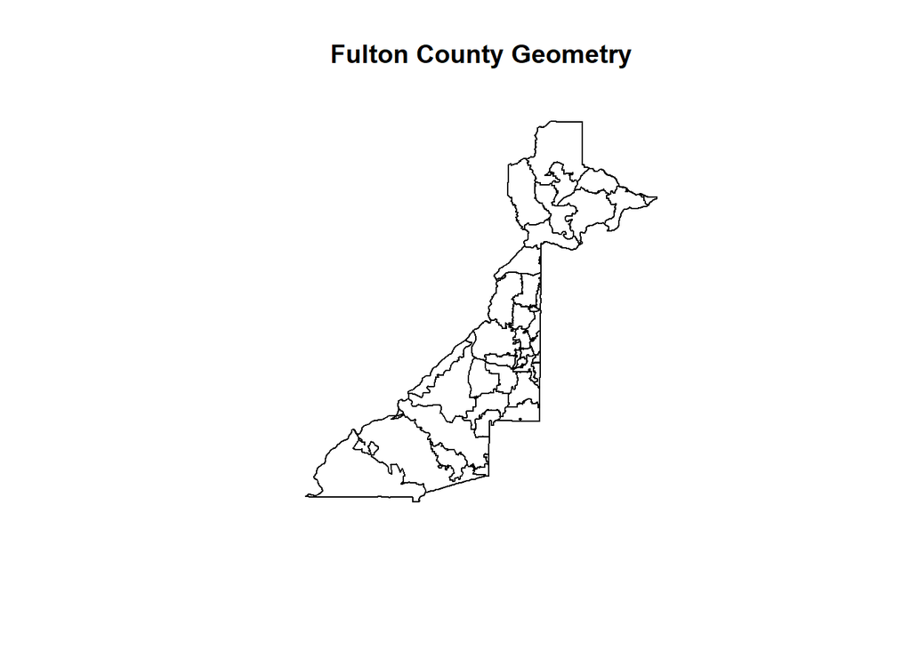

## Pull data of interest and summarize by zipcode

## Then merge and make a choropleth map

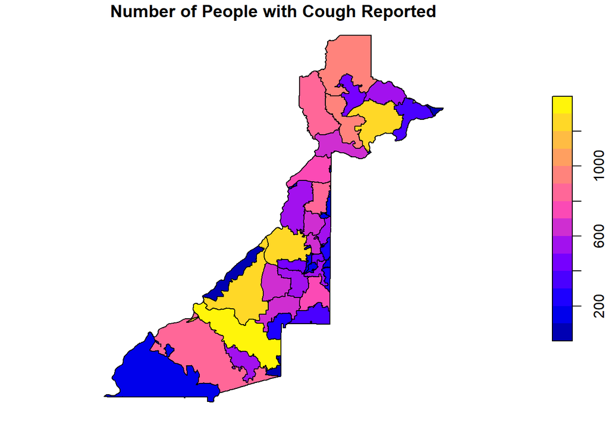

## Another map option with ggplot2

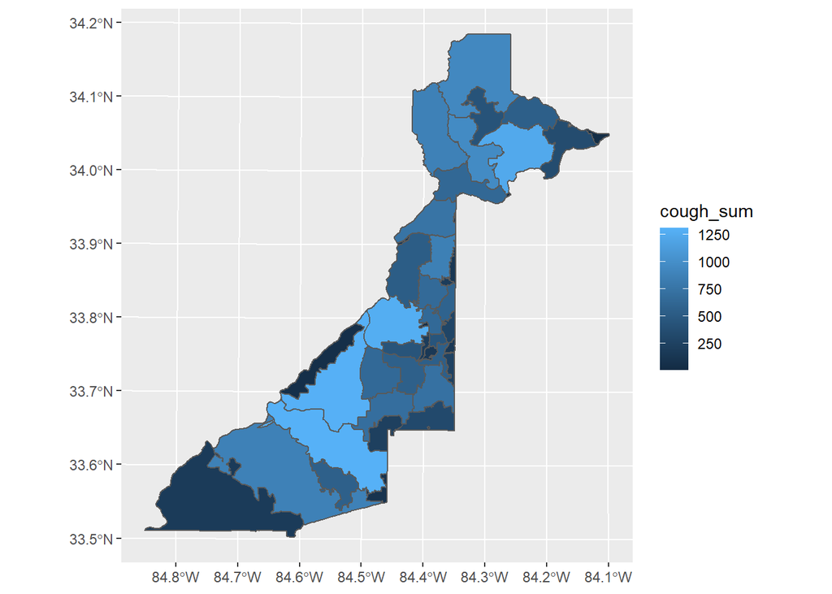